# Linear Regression v3

Casey Bates

11/2/2018

We’ll start by pulling in the clean dataset with the Rifle outliers removed.

```r
library(tidyverse)
no_zeros <- read_csv("garfield_no_zeros_clean.csv")
```

Now we will see how the models change when predicting sale price by square footage and baths (which showed a correlation coefficient of 0.52).

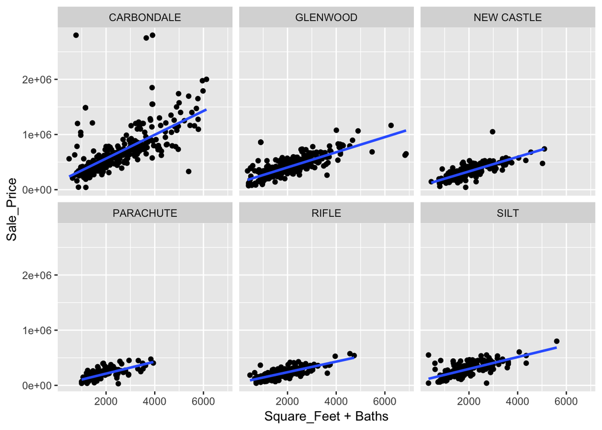

```r
ggplot(data = no_zeros, aes(x = Square_Feet + Baths, y = Sale_Price)) +
  geom_point() +
  geom_smooth(method = "lm", se = FALSE) +
  facet_wrap(~ Location)
```

Now the model for Rifle fits much better and the outliers are no longer visible.

```r
library(broom)
# David Robinson's Steps 1 thru 4 on training dataset
coefficients <- no_zeros %>%
  nest(-Location) %>%
  mutate(models = map(data, ~lm(Sale_Price ~ Square_Feet + Baths, .))) %>%
  mutate(tidied = map(models, tidy)) %>%
  unnest(tidied)
#Filter for slope values for each location and arrange
coefficients %>% filter(term=="Square_Feet") %>% arrange(estimate)
```

```
## # A tibble: 6 x 6
##   Location   term        estimate std.error statistic  p.value
##   <chr>      <chr>          <dbl>     <dbl>     <dbl>    <dbl>
## 1 RIFLE      Square_Feet     100.      5.65     17.7  3.88e-51
## 2 SILT       Square_Feet     111.     12.4       8.90 2.10e-16
## 3 PARACHUTE  Square_Feet     113.      9.89     11.4  1.53e-23
## 4 NEW CASTLE Square_Feet     122.      7.70     15.9  2.41e-42
## 5 GLENWOOD   Square_Feet     137.      9.15     15.0  2.57e-41
## 6 CARBONDALE Square_Feet     251.     21.3      11.8  2.29e-27
```

This updated p-value for Rifle also indicates that we have a much better fit.

#Many models with purrr and broom R4DS approach to this dataset (Chapter 20) The models capture how square feet influences sale price, and the residuals show what’s left.

```r
library(modelr)
```

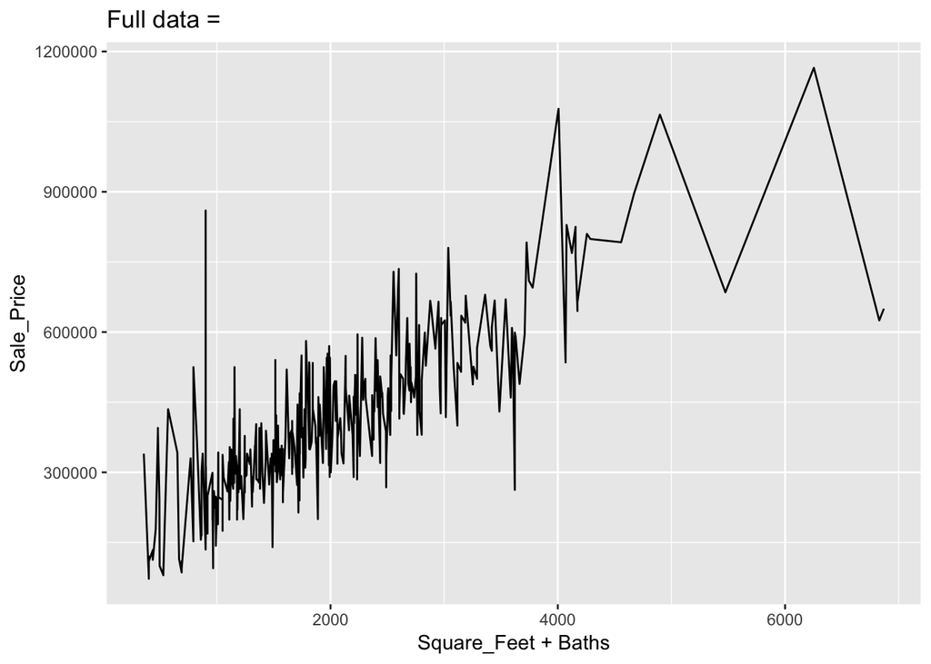

```r
glenwood <- filter(no_zeros, Location == "GLENWOOD")
glenwood %>%
  ggplot(aes(Square_Feet + Baths, Sale_Price)) +
  geom_line() +
  ggtitle("Full data = ")
```

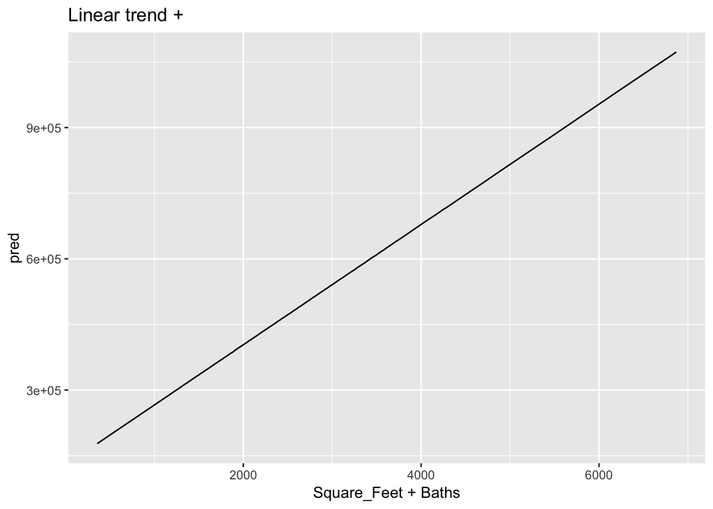

```r
glenwood_mod <- lm(Sale_Price ~ Square_Feet + Baths, data = glenwood)
glenwood %>%
  add_predictions(glenwood_mod) %>%
  ggplot(aes(Square_Feet + Baths, pred)) +
  geom_line() +
  ggtitle("Linear trend + ")
```

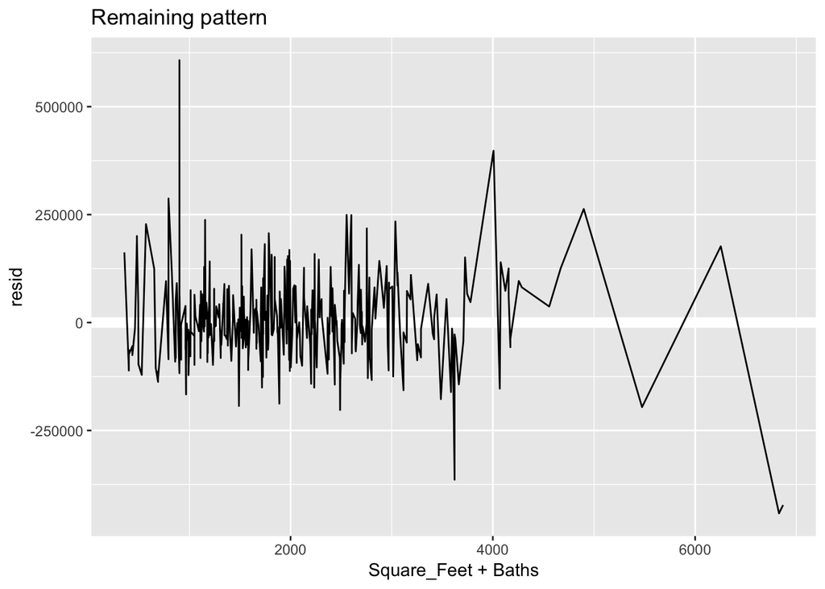

```r
glenwood %>%
  add_residuals(glenwood_mod) %>%
  ggplot(aes(Square_Feet + Baths, resid)) +
  geom_hline(yintercept = 0, color = "white", size = 3) +
  geom_line() +
  ggtitle("Remaining pattern")
```

To repeat the above for all six locations, we will need to create a nested dataframe to repeat this action for each location using purrr. We’ve seen how to do this above, but now we will try the approach outlined by Hadley Wickam.

```r
by_location <- no_zeros %>%
  group_by(Location) %>%
  nest()
by_location
```

```
## # A tibble: 6 x 2
##   Location   data
##   <chr>      <list>
## 1 CARBONDALE <tibble [376 × 12]>
## 2 GLENWOOD   <tibble [440 × 12]>
## 3 NEW CASTLE <tibble [326 × 12]>
## 4 PARACHUTE  <tibble [201 × 12]>
## 5 RIFLE      <tibble [370 × 12]>
## 6 SILT       <tibble [223 × 12]>
```

```r
# Equivalent method outlined by David Robinson used above would be:
#by_location <- no_zeros %>%
  #nest(-Location)
```

According to Wickam, there is no great way to explore the nested dataframes. So the best thing we can do is inspect one of them:

```r
by_location$data[[4]] #Parachute
```

```
## # A tibble: 201 x 12
##    Index Inspection_Date Sale_Date  Sale_Price Classification
##    <int> <date>          <date>          <int> <chr>
##  1   429 2014-09-12      2014-10-17      65500 Townhome
##  2   430 2016-05-26      2016-06-30     110000 Townhome
##  3   431 2016-01-28      2016-03-03     106000 Townhome
##  4   432 2015-09-21      2015-10-26      67000 Townhome
##  5   433 2015-06-01      2015-07-06     140000 Townhome
##  6   434 2015-02-18      2015-03-25      89270 Townhome
##  7   435 2015-10-27      2015-12-01     110000 Townhome
##  8   436 2015-09-18      2015-10-23     122000 Townhome
##  9   437 2015-05-27      2015-07-01     243842 Townhome
## 10   438 2015-04-29      2015-06-03     147000 Townhome
## # ... with 191 more rows, and 7 more variables: Architectural_Style <chr>,
## #   Year_Built <dbl>, Bedrooms <int>, Baths <dbl>, Square_Feet <dbl>,
## #   Count <int>, Price_per_SF <dbl>
```

Now that we have our nested dataframe we’re in a good position to fit some models. Here is the model fitting function:

```r
location_model <- function(df){
  lm(Sale_Price ~ Square_Feet + Baths, data = df)
}
```

And we want to apply it to every data frame. The dataframes are in a list, so we can use purrrr::map() to apply location_model to each element:

```r
# models <- map(by_location$data, location_model)
```

However, rather than leaving the list of models as a free-floating element (as stated by Wickam) it’s better to store this information as a column in the by_location dataframe.

```r
by_location <- by_location %>%
  mutate(model = map(data, location_model))
by_location
```

```
## # A tibble: 6 x 3
##   Location   data                model
##   <chr>      <list>              <list>
## 1 CARBONDALE <tibble [376 × 12]> <S3: lm>
## 2 GLENWOOD   <tibble [440 × 12]> <S3: lm>
## 3 NEW CASTLE <tibble [326 × 12]> <S3: lm>
## 4 PARACHUTE  <tibble [201 × 12]> <S3: lm>
## 5 RIFLE      <tibble [370 × 12]> <S3: lm>
## 6 SILT       <tibble [223 × 12]> <S3: lm>
```

The above is a similar approach to that taught by David Robinson except that Wickam abstracted away the linear modeling by creating the location_model function first.

Wickam: This has a big advantage: because all the related objects are stored together, you don’t need to manually keep them in sync when you filter or arrange. The semantics of the dataframe take care of that for you:

```r
by_location %>%
  filter(Location == "SILT")
```

```
## # A tibble: 1 x 3
##   Location data                model
##   <chr>    <list>              <list>
## 1 SILT     <tibble [223 × 12]> <S3: lm>
```

Or arrange:

```r
by_location %>%
  arrange(Location)
```

```
## # A tibble: 6 x 3
##   Location   data                model
##   <chr>      <list>              <list>
## 1 CARBONDALE <tibble [376 × 12]> <S3: lm>
## 2 GLENWOOD   <tibble [440 × 12]> <S3: lm>
## 3 NEW CASTLE <tibble [326 × 12]> <S3: lm>
## 4 PARACHUTE  <tibble [201 × 12]> <S3: lm>
## 5 RIFLE      <tibble [370 × 12]> <S3: lm>
## 6 SILT       <tibble [223 × 12]> <S3: lm>
```

Keeping everything in one place keeps you from reordering or subsetting objects in different ways!

To compute the residuals for all dataframes we will call add_residuals() with each model-data pair:

```r
by_location <- by_location %>%
  mutate(
    resids = map2(data, model, add_residuals)
  )
by_location
```

```
## # A tibble: 6 x 4
##   Location   data                model    resids
##   <chr>      <list>              <list>   <list>
## 1 CARBONDALE <tibble [376 × 12]> <S3: lm> <tibble [376 × 13]>
## 2 GLENWOOD   <tibble [440 × 12]> <S3: lm> <tibble [440 × 13]>
## 3 NEW CASTLE <tibble [326 × 12]> <S3: lm> <tibble [326 × 13]>
## 4 PARACHUTE  <tibble [201 × 12]> <S3: lm> <tibble [201 × 13]>
## 5 RIFLE      <tibble [370 × 12]> <S3: lm> <tibble [370 × 13]>
## 6 SILT       <tibble [223 × 12]> <S3: lm> <tibble [223 × 13]>
```

Now to inspect one of the resids dataframes:

```r
head(by_location$resids[[2]])
```

```
## # A tibble: 6 x 13
##   Index Inspection_Date Sale_Date  Sale_Price Classification
##   <int> <date>          <date>          <int> <chr>
## 1   137 2015-07-24      2015-08-28      75000 Condo
## 2   138 2015-05-18      2015-06-22      84900 Condo
## 3   139 2015-05-08      2015-06-12      80000 Condo
## 4   140 2015-09-10      2015-10-15      72500 Condo
## 5   141 2015-08-13      2015-09-17     120000 Condo
## 6   142 2016-02-25      2016-03-31      82500 Condo
## # ... with 8 more variables: Architectural_Style <chr>, Year_Built <dbl>,
## #   Bedrooms <int>, Baths <dbl>, Square_Feet <dbl>, Count <int>,
## #   Price_per_SF <dbl>, resid <dbl>
```

How can you plot a list of dataframes? If we want to plot the residuals we will need to unnest this list of dataframes, like so:

```r
resids <- unnest(by_location, resids)
resids
```

```
## # A tibble: 1,936 x 14
##    Location Index Inspection_Date Sale_Date  Sale_Price Classification
##    <chr>    <int> <date>          <date>          <int> <chr>
##  1 CARBOND…     0 2014-07-04      2014-08-08     210000 Condo
##  2 CARBOND…     1 2015-11-06      2015-12-11     265000 Condo
##  3 CARBOND…     2 2015-03-10      2015-04-14     308500 Condo
##  4 CARBOND…     3 2015-12-16      2016-01-20     160000 Condo
##  5 CARBOND…     4 2016-03-04      2016-04-08     340000 Condo
##  6 CARBOND…     5 2014-05-27      2014-07-01      45000 Condo
##  7 CARBOND…     6 2015-07-24      2015-08-28     251200 Condo
##  8 CARBOND…     7 2016-05-03      2016-06-07     275500 Condo
##  9 CARBOND…     8 2015-04-27      2015-06-01     323000 Condo
## 10 CARBOND…     9 2015-11-12      2015-12-17     323000 Condo
## # ... with 1,926 more rows, and 8 more variables:
## #   Architectural_Style <chr>, Year_Built <dbl>, Bedrooms <int>,
## #   Baths <dbl>, Square_Feet <dbl>, Count <int>, Price_per_SF <dbl>,
## #   resid <dbl>
```

Wickam: Each regular column is repeated once for each row in the nested column. Now that we have a regular dataframe we can plot the residuals:

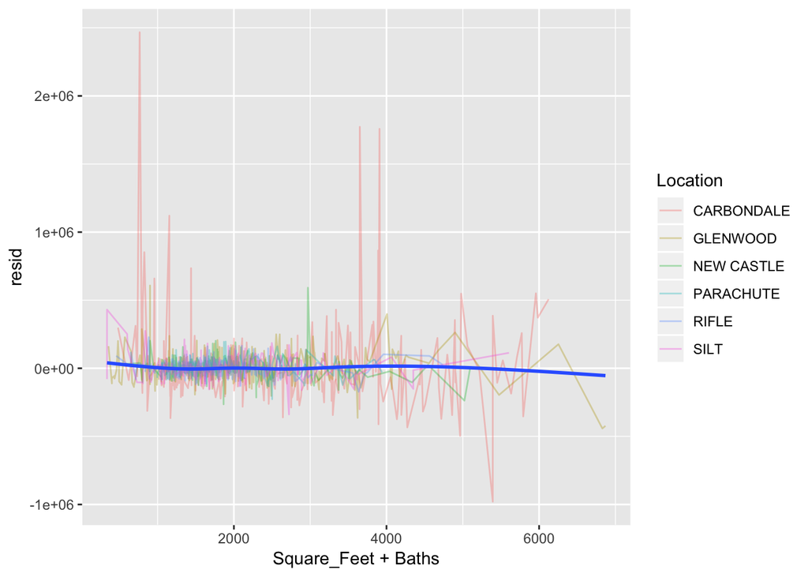

```r
resids %>%
  ggplot(aes(Square_Feet + Baths, resid)) + #resid is a column in the tibbles within the resids list column
  geom_line(aes(group = Location, color=Location), alpha = 1 / 3) +
  geom_smooth(se = FALSE)
```

Or, facet by location:

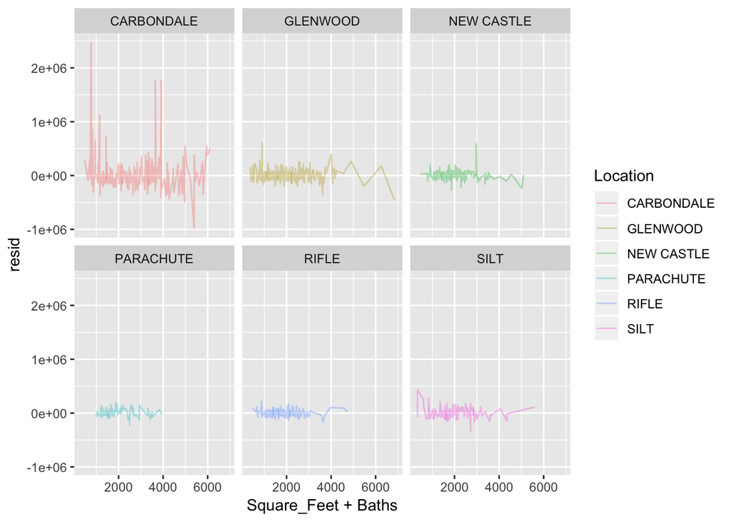

```r
resids %>%
  ggplot(aes(Square_Feet + Baths, resid, color = Location)) +
  geom_line(alpha = 1 / 3) +
  facet_wrap(~Location)
```

#Model Quality (repeated from initial linear regression file) Wickam: Instead of looking at residuals from the model we could look at some general measurements of model quality using broom::glance(). If we apply it to a model, we get a dataframe with a single row.

```r
broom::glance(glenwood_mod)
```

```
## # A tibble: 1 x 11
##   r.squared adj.r.squared  sigma statistic  p.value    df logLik    AIC
## *     <dbl>         <dbl>  <dbl>     <dbl>    <dbl> <int>  <dbl>  <dbl>
## 1     0.598         0.596 1.12e5      325. 3.39e-87     3 -5737. 11483.
## # ... with 3 more variables: BIC <dbl>, deviance <dbl>, df.residual <int>
```

We can use `mutate()` and `unnest()` to create a dataframe with a row for each location:

```r
by_location %>%
  mutate(glance = map(model, broom::glance)) %>%
  unnest(glance)
```

```
## # A tibble: 6 x 15
##   Location data  model resids r.squared adj.r.squared  sigma statistic
##   <chr>    <lis> <lis> <list>     <dbl>         <dbl>  <dbl>     <dbl>
## 1 CARBOND… <tib… <S3:… <tibb…     0.473         0.470 2.81e5     167.
## 2 GLENWOOD <tib… <S3:… <tibb…     0.598         0.596 1.12e5     325.
## 3 NEW CAS… <tib… <S3:… <tibb…     0.637         0.635 7.22e4     283.
## 4 PARACHU… <tib… <S3:… <tibb…     0.509         0.504 5.99e4     103.
## 5 RIFLE    <tib… <S3:… <tibb…     0.540         0.537 5.23e4     215.
## 6 SILT     <tib… <S3:… <tibb…     0.472         0.467 8.57e4      98.1
## # ... with 7 more variables: p.value <dbl>, df <int>, logLik <dbl>,
## #   AIC <dbl>, BIC <dbl>, deviance <dbl>, df.residual <int>
```

This still includes the list columns. This is the default behavior when `unnest()` works on single-row dataframes. To supress these columns we use .drop = TRUE:

```r
glance <- by_location %>%
  mutate(glance = map(model, broom::glance)) %>%
  unnest(glance, .drop = TRUE)
glance
```

```
## # A tibble: 6 x 12
##   Location r.squared adj.r.squared  sigma statistic  p.value    df logLik
##   <chr>        <dbl>         <dbl>  <dbl>     <dbl>    <dbl> <int>  <dbl>
## 1 CARBOND…     0.473         0.470 2.81e5     167.  1.32e-52     3 -5249.
## 2 GLENWOOD     0.598         0.596 1.12e5     325.  3.39e-87     3 -5737.
## 3 NEW CAS…     0.637         0.635 7.22e4     283.  8.94e-72     3 -4108.
## 4 PARACHU…     0.509         0.504 5.99e4     103.  2.65e-31     3 -2495.
## 5 RIFLE        0.540         0.537 5.23e4     215.  1.54e-62     3 -4543.
## 6 SILT         0.472         0.467 8.57e4      98.1 3.41e-31     3 -2848.
## # ... with 4 more variables: AIC <dbl>, BIC <dbl>, deviance <dbl>,
## #   df.residual <int>
```

Now we can look at model fit:

```r
glance %>%
  arrange(r.squared)
```

```
## # A tibble: 6 x 12
##   Location r.squared adj.r.squared  sigma statistic  p.value    df logLik
##   <chr>        <dbl>         <dbl>  <dbl>     <dbl>    <dbl> <int>  <dbl>
## 1 SILT         0.472         0.467 8.57e4      98.1 3.41e-31     3 -2848.
## 2 CARBOND…     0.473         0.470 2.81e5     167.  1.32e-52     3 -5249.
## 3 PARACHU…     0.509         0.504 5.99e4     103.  2.65e-31     3 -2495.
## 4 RIFLE        0.540         0.537 5.23e4     215.  1.54e-62     3 -4543.
## 5 GLENWOOD     0.598         0.596 1.12e5     325.  3.39e-87     3 -5737.
## 6 NEW CAS…     0.637         0.635 7.22e4     283.  8.94e-72     3 -4108.
## # ... with 4 more variables: AIC <dbl>, BIC <dbl>, deviance <dbl>,
## #   df.residual <int>
```

The model looks much better for Rifle now that the outliers have been removed from the dataset.

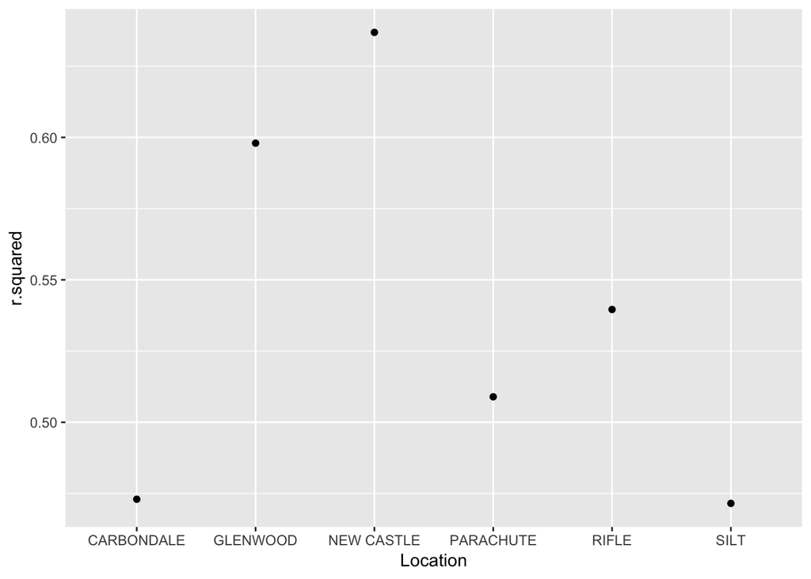

```r
glance %>%
  ggplot(aes(Location, r.squared)) +
  geom_point()
```

#Creating a training and test set to compare model results. To compare model quality I will create a training and test set as per this [method](https://rpubs.com/ID_Tech/S1).

```r
smp_siz <-  floor(0.8*nrow(no_zeros))  # creates a value for dividing the data into train and test. In this case the value is defined as 80% of the number of rows in the dataset
smp_siz  # shows the value of the sample size
```

```
## [1] 1548
```

```r
set.seed(123)   # set seed to ensure you always have same random numbers generated
train_ind <-  sample(seq_len(nrow(no_zeros)),size = smp_siz)  # Randomly identifies therows equal to sample size ( defined in previous instruction) from  all the rows of no_zeros dataset and stores the row number in train_ind
train <- no_zeros[train_ind,] #creates the training dataset with row numbers stored in train_ind
test <- no_zeros[-train_ind,] # creates the test dataset excluding the row numbers mentioned in train_ind
```

I’ll start with some visualizations comparing the two datasets.

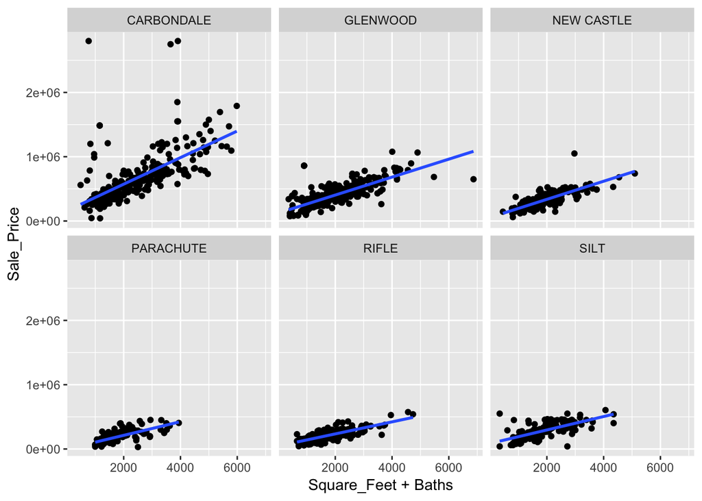

```r
#Training dataset
ggplot(data = train, aes(x = Square_Feet + Baths, y = Sale_Price)) +
  geom_point() +
  geom_smooth(method = "lm", se = FALSE) +
  facet_wrap(~ Location)
```

And the test dataset:

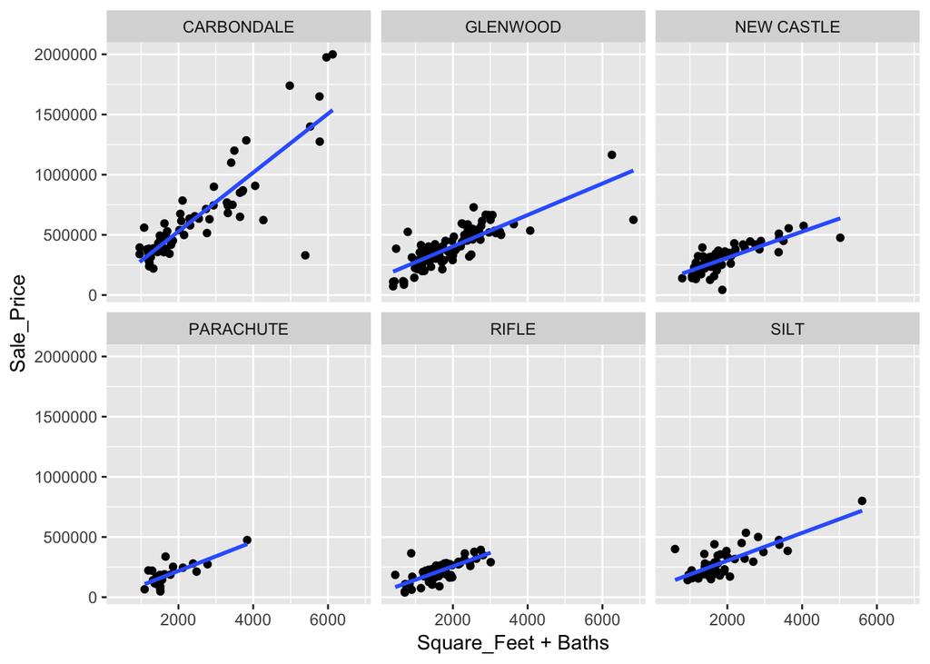

```r
#Test dataset
ggplot(data = test, aes(x = Square_Feet + Baths, y = Sale_Price)) +
  geom_point() +
  geom_smooth(method = "lm", se = FALSE) +
  facet_wrap(~ Location)
```

Now to compare the modeling coefficients of each using David Robinson’s 4 step approach.

```r
# David Robinson's Steps 1 thru 4 on training dataset
train_coefficients <- train %>%
  nest(-Location) %>%
  mutate(models = map(data, ~lm(Sale_Price ~ Square_Feet + Baths, .))) %>%
  mutate(tidied = map(models, tidy)) %>%
  unnest(tidied)
#Filter for slope values for each location and arrange
train_coefficients %>% filter(term=="Square_Feet") %>% arrange(estimate)
```

```
## # A tibble: 6 x 6
##   Location   term        estimate std.error statistic  p.value
##   <chr>      <chr>          <dbl>     <dbl>     <dbl>    <dbl>
## 1 RIFLE      Square_Feet     98.7      5.89     16.8  1.40e-44
## 2 SILT       Square_Feet    107.      14.0       7.63 1.43e-12
## 3 PARACHUTE  Square_Feet    110.      10.5      10.4  5.38e-20
## 4 NEW CASTLE Square_Feet    132.       8.76     15.1  2.08e-37
## 5 GLENWOOD   Square_Feet    144.      10.7      13.4  3.04e-33
## 6 CARBONDALE Square_Feet    243.      24.7       9.87 4.33e-20
```

```r
# David Robinson's Steps 1 thru 4 on test dataset
test_coefficients <- test %>%
  nest(-Location) %>%
  mutate(models = map(data, ~lm(Sale_Price ~ Square_Feet + Baths, .))) %>%
  mutate(tidied = map(models, tidy)) %>%
  unnest(tidied)
#Filter for slope values for each location and arrange
test_coefficients %>% filter(term=="Square_Feet") %>% arrange(estimate)
```

```
## # A tibble: 6 x 6
##   Location   term        estimate std.error statistic       p.value
##   <chr>      <chr>          <dbl>     <dbl>     <dbl>         <dbl>
## 1 NEW CASTLE Square_Feet     93.7      15.2      6.18 0.0000000589
## 2 GLENWOOD   Square_Feet    111.       17.0      6.57 0.00000000240
## 3 RIFLE      Square_Feet    118.       17.0      6.94 0.00000000135
## 4 SILT       Square_Feet    127.       28.0      4.53 0.0000480
## 5 PARACHUTE  Square_Feet    147.       33.8      4.34 0.000193
## 6 CARBONDALE Square_Feet    260.       40.7      6.39 0.0000000165
```

Overall the results look reasonably close between the training set and the test set. What about using the approach above with `broom::glance()` instead of `broom::tidy()`? The approach below combines David Robinson’s 4-step approach with the `broom::glance()` example described by Wickam.

```r
train_glance <- train %>%
  nest(-Location) %>%
  mutate(models = map(data, ~lm(Sale_Price ~ Square_Feet + Baths, .))) %>%
  mutate(glance = map(models, broom::glance)) %>%
  unnest(glance, .drop = TRUE)
train_glance%>% arrange(r.squared)
```

```
## # A tibble: 6 x 12
##   Location r.squared adj.r.squared  sigma statistic  p.value    df logLik
##   <chr>        <dbl>         <dbl>  <dbl>     <dbl>    <dbl> <int>  <dbl>
## 1 CARBOND…     0.412         0.408 2.96e5     106.  1.90e-35     3 -4260.
## 2 SILT         0.432         0.425 8.64e4      66.5 3.30e-22     3 -2274.
## 3 PARACHU…     0.493         0.487 6.08e4      82.1 1.22e-25     3 -2137.
## 4 RIFLE        0.559         0.556 5.07e4     185.  1.69e-52     3 -3601.
## 5 GLENWOOD     0.583         0.580 1.16e5     234.  2.76e-64     3 -4420.
## 6 NEW CAS…     0.652         0.650 7.15e4     243.  3.90e-60     3 -3299.
## # ... with 4 more variables: AIC <dbl>, BIC <dbl>, deviance <dbl>,
## #   df.residual <int>
```

In the results above you can see that everything is already arranged by r.squared, lowest to highest.

```r
test_glance <- test %>%
  nest(-Location) %>%
  mutate(models = map(data, ~lm(Sale_Price ~ Square_Feet + Baths, .))) %>%
  mutate(glance = map(models, broom::glance)) %>%
  unnest(glance, .drop = TRUE)
test_glance %>% arrange(r.squared)
```

```
## # A tibble: 6 x 12
##   Location r.squared adj.r.squared  sigma statistic  p.value    df logLik
##   <chr>        <dbl>         <dbl>  <dbl>     <dbl>    <dbl> <int>  <dbl>
## 1 RIFLE        0.514         0.501 5.63e4      38.6 3.60e-12     3  -938.
## 2 SILT         0.596         0.576 8.50e4      30.9 5.56e- 9     3  -573.
## 3 PARACHU…     0.618         0.589 5.63e4      21.0 3.70e- 6     3  -357.
## 4 NEW CAS…     0.640         0.628 6.97e4      54.1 3.04e-14     3  -803.
## 5 GLENWOOD     0.668         0.662 9.58e4      99.7 1.90e-24     3 -1313.
## 6 CARBOND…     0.742         0.734 2.02e5      99.0 5.32e-21     3  -980.
## # ... with 4 more variables: AIC <dbl>, BIC <dbl>, deviance <dbl>,
## #   df.residual <int>
```

What about augment? Can we apply the 4-step process to this too?

```r
train_augment <- train %>%
  nest(-Location) %>%
  mutate(models = map(data, ~lm(Sale_Price ~ Square_Feet + Baths, .))) %>%
  mutate(augment = map(models, broom::augment)) %>%
  unnest(augment)
train_augment
```

```
## # A tibble: 1,548 x 11
##    Location Sale_Price Square_Feet Baths .fitted .se.fit  .resid    .hat
##    <chr>         <int>       <dbl> <dbl>   <dbl>   <dbl>   <dbl>   <dbl>
##  1 SILT         190000        1274  2.5  217468.  14348. -27468. 0.0276
##  2 SILT         240000        1588  2    252661.   6859. -12661. 0.00630
##  3 SILT         289000        1766  2.5  270016.   9206.  18984. 0.0113
##  4 SILT         179000        1674  2    261846.   6667. -82846. 0.00595
##  5 SILT         455000        2613  3    358821.  11101.  96179. 0.0165
##  6 SILT         187500        1230  2    214426.   9431. -26926. 0.0119
##  7 SILT         304000        1732  2.5  266384.   9490.  37616. 0.0121
##  8 SILT         540000        4348  3.25 543297.  25311.  -3297. 0.0857
##  9 SILT         295000        1633  2    257467.   6732.  37533. 0.00607
## 10 SILT         487500        3164  2.75 418498.  14368.  69002. 0.0276
## # ... with 1,538 more rows, and 3 more variables: .sigma <dbl>,
## #   .cooksd <dbl>, .std.resid <dbl>
```

What about augment? Can we apply the 4-step process to this too?

```r
test_augment <- test %>%
  nest(-Location) %>%
  mutate(models = map(data, ~lm(Sale_Price ~ Square_Feet + Baths, .))) %>%
  mutate(augment = map(models, broom::augment)) %>%
  unnest(augment)
test_augment
```

```
## # A tibble: 388 x 11
##    Location Sale_Price Square_Feet Baths .fitted .se.fit  .resid   .hat
##    <chr>         <int>       <dbl> <dbl>   <dbl>   <dbl>   <dbl>  <dbl>
##  1 CARBOND…     290000        1200  1.7  340688.  36610. -50688. 0.0330
##  2 CARBOND…     354000        1200  2.5  321623.  42374.  32377. 0.0442
##  3 CARBOND…     339000        1200  2.5  321623.  42374.  17377. 0.0442
##  4 CARBOND…     375000        1210  2.25 330183.  34549.  44817. 0.0294
##  5 CARBOND…     385000        1210  2.25 330183.  34549.  54817. 0.0294
##  6 CARBOND…     280000        1215  2    337441.  31911. -57441. 0.0251
##  7 CARBOND…     239000        1215  2    337441.  31911. -98441. 0.0251
##  8 CARBOND…     265000        1224  1.5  351698.  43637. -86698. 0.0469
##  9 CARBOND…     315500        1260  1.75 355106.  35702. -39606. 0.0314
## 10 CARBOND…     387500        1326  2    366320.  31087.  21180. 0.0238
## # ... with 378 more rows, and 3 more variables: .sigma <dbl>,
## #   .cooksd <dbl>, .std.resid <dbl>
```